# Statistical Methods for Insurance: Statistical distributions

W3.C2

## Overview of this class

- Random variables
- Central limit theorem
- Estimation
- Quantiles
- Goodness of fit
- READING: CT6, Section 1.3-1.9

## Random variables vs random samples

- Conceptually we think about a **random variable** \((X)\) having a distribution

\[X \sim N(\mu, \sigma)\]

- Once we collect data, or use simulation we will have a realisation from the distribution, a random sample, observed values:

```
#> [1]  1.06 -0.18  0.63  1.14  1.29
```

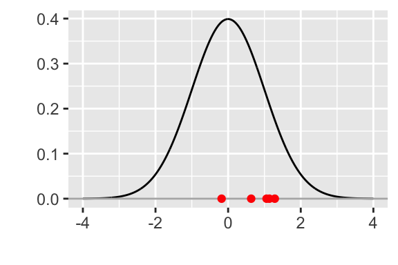

## Central limit theorem

- Why the normal model is so fundamental
- Regardless what distribution \(X\) has, the mean of a sample will have a normal distribution, if the sample size is large:

"Let \(\{X_1, ..., X_n\}\) be a random sample of size \(n\) — that is, a sequence of independent and identically distributed random variables drawn from a distribution mean given by \(\mu\) and finite variance given by \(\sigma^2\). The sample average is defined \(\bar{X} = \sum_{i=1}^{n} X_i/n\), then as \(n\) gets large the distribution of \(\bar{X}\) approximates \(N(\mu, \sigma/\sqrt{n})\)."

## Example: Uniform parent

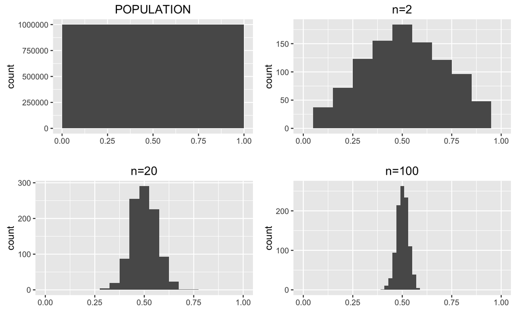

## Example: Weibull parent

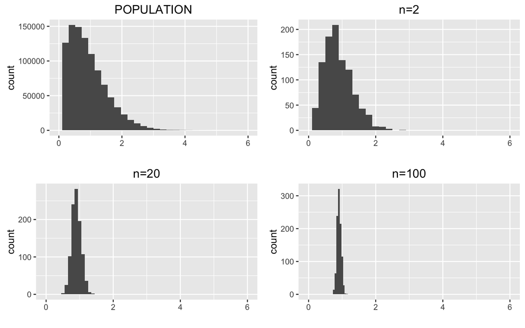

## Estimation

- Estimate parameters of a distribution from the sample data
- Common approach is maximum likelihood estimation
- Requires assuming we know the basic functional form

## Maximum likelihood estimate (MLE)

- Estimate the unknown parameter \(\theta\) using the value that maximises the probability (i.e. likelihood) of getting the observed sample
- Likelihood function

\[ \begin{aligned} L(\theta) &=P(X_1=x_1,X_2=x_2, ... ,X_n=x_n~|~\theta) \\ &=f(x_1|\theta)f(x_2|\theta)\cdots f(x_n|\theta) \\ &=\prod_{i=1}^n f(x_i;\theta) \end{aligned} \]

- This is now a function of \(\theta\).
- Use function maximisation to solve.

## Example - Mean of normal distribution, assume variance is 1

- MLE estimate of the population mean for a normal model is the sample mean
- Run this numerically
- Suppose we have a sample of two: \(x_1=1.0, x_2=3.0\)
- Likelihood

\[ \begin{aligned} L(\mu) &= \frac{1}{\sqrt{2\pi}}e^{-\frac{(1.0-\mu)^2}{2}}\times \frac{1}{\sqrt{2\pi}}e^{-\frac{(3.0-\mu)^2}{2}}\\ &= \frac{1}{2\pi}e^{-\frac{(1-\mu)^2+(3-\mu)^2}{2}} \end{aligned} \]

## Plot it

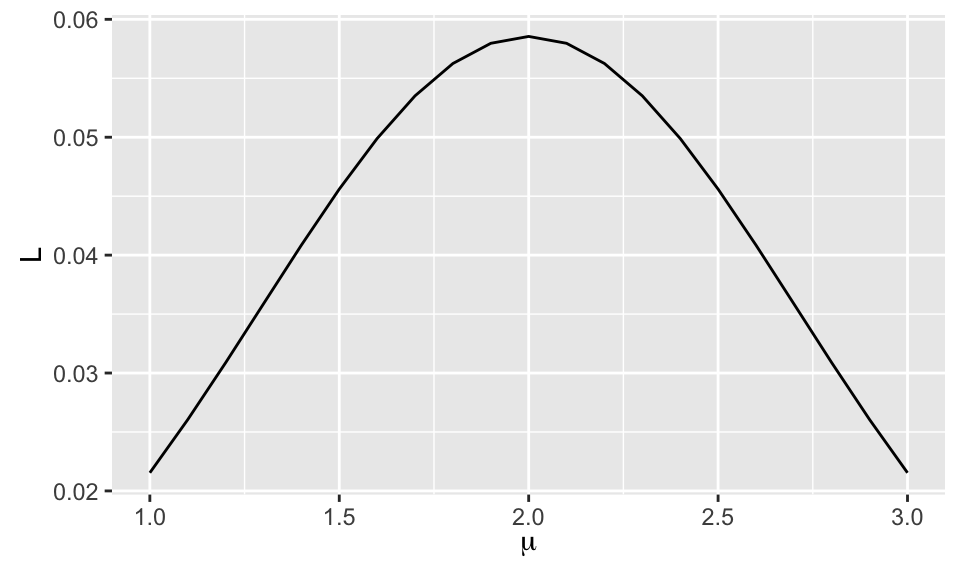

- The maximum is at 2.0. This is the sample mean, which we can prove algebraically is the MLE.

## Estimate mean and variance

Sample

```
#>  [1]  7.31  3.96  2.34  0.55  5.12 10.33  3.74 -6.30 -1.14  6.55  9.13
#> [12] 10.34  5.93  1.72  3.71  3.68 -1.36 11.71  1.99  5.13  8.35  7.50
```

We know it comes from a normal distribution. What are the best guesses for the \(\mu, \sigma\)?

Compute the likelihood for a range of values of both parameters.

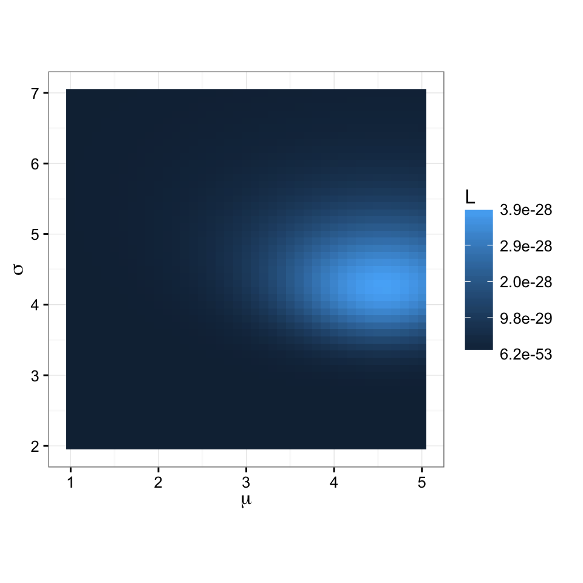

## Quantiles

- `quantiles` are cutpoints dividing the range of a probability distribution into contiguous intervals with equal probabilities
- 2-quantile is the median (divides the population into two equal halves)
- 4-quantile are quartiles, \(Q_1, Q_2, Q_3\), dividing the population into four equal chunks
- quantiles are values of the random variable \(X\)
- useful for comparing distributions

## Example:

- 12-quantiles for a \(N(0,1)\)

```r
qnorm(seq(1/12,11/12,1/12))
```

```
#>  [1] -1.4e+00 -9.7e-01 -6.7e-01 -4.3e-01 -2.1e-01 -1.4e-16  2.1e-01
#>  [8]  4.3e-01  6.7e-01  9.7e-01  1.4e+00
```

- 23-quantiles from a \(Gamma(2,1)\)

```r
qgamma(seq(1/23,22/23,1/23), 2)
```

```
#>  [1] 0.33 0.49 0.63 0.75 0.87 0.99 1.11 1.23 1.35 1.48 1.61 1.75 1.90 2.06
#> [15] 2.23 2.42 2.63 2.88 3.18 3.55 4.06 4.91
```

## Percentiles

- indicate the value of \(X\) below which a given percentage of observations fall, e.g. 20th percentile is the value that has 20% of values below it
- 17th percentile from \(N(0,1)\)

```r
qnorm(0.17)
```

```
#> [1] -0.95
```

- 78th percentile from \(Gamma(2,1)\)

```r
qgamma(0.78, 2)
```

```
#> [1] 2.9
```

## Goodness of fit

- Quantile-quantile plot (QQplot) plots theoretical vs sample quantiles
- Lets check the distribution of PISA math scores

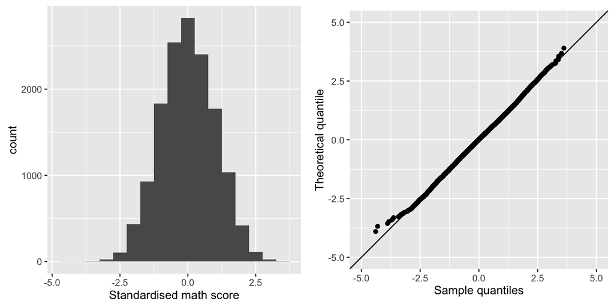

## QQ-Plot computation

1. Sort and standardise the sample values from low to high
2. Theoretical quantiles, \(n=\) sample size \[ 1 - 0.5^{(1/n)} ~~~ i=1 \\ ~~~~~~~~~~~~~\frac{i - 0.3175}{n + 0.365} ~~~ i=2, ..., n-1 \\ 0.5^{(1/n)} ~~~~~~ ~~~ i=n \]
3. Plot the theoretical vs sample quantiles

## Reading QQ-plots

- The points should lie along the \(X=Y\) line, for the sample to be consistent with the distribution.
- How close is good enough?
- It depends on the sample size.
- Simulate some samples of the same size from the target distribution, and make QQ-plots of these, to compare with the actual data

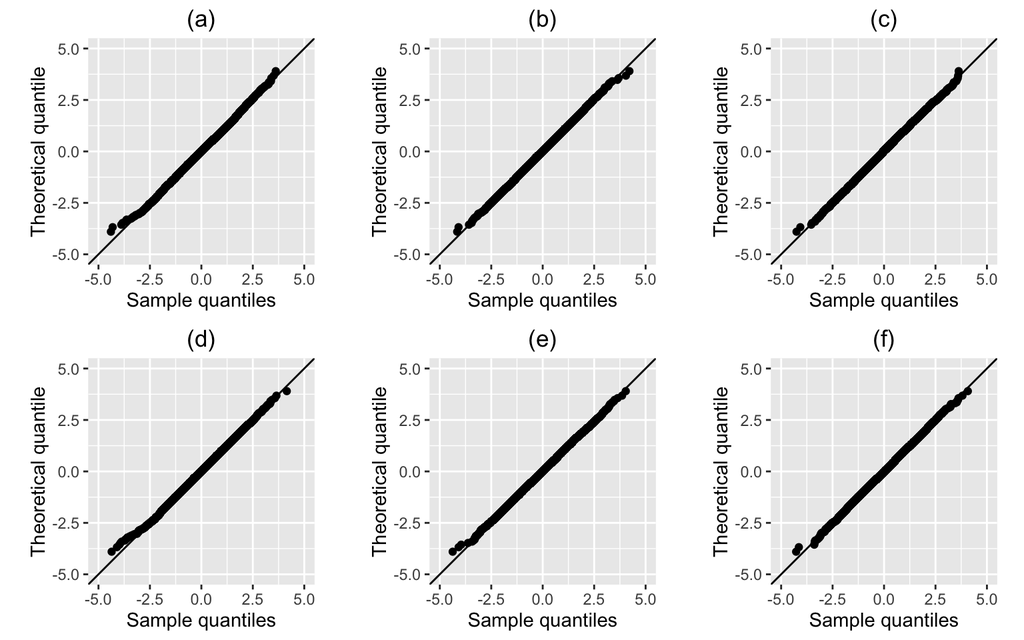

## How different is exponential from Pareto?

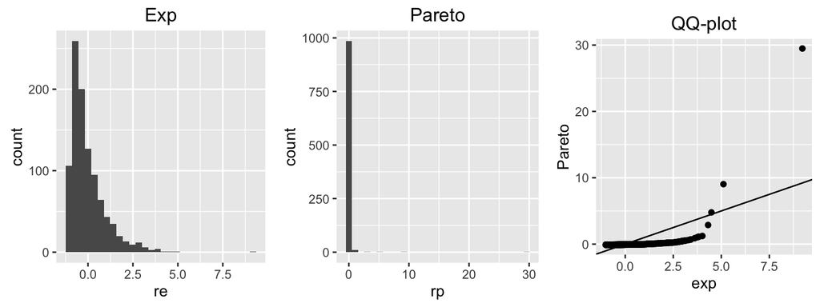

## How different can exponentials be?

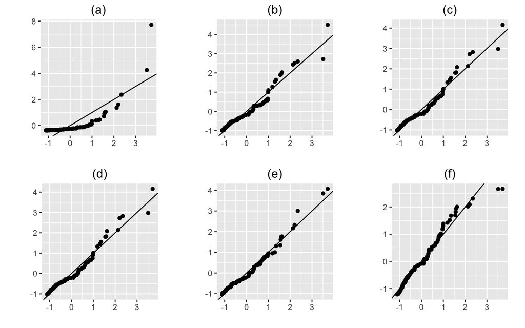

## Resources

- [wikipedia](https://en.wikipedia.org/wiki/Quantile)
- [PSU 414](https://onlinecourses.science.psu.edu/stat414/node/191)

## Share and share alike

This work is licensed under the Creative Commons Attribution-Noncommercial 3.0 United States License. To view a copy of this license, visit http://creativecommons.org/licenses/by-nc/ 3.0/us/ or send a letter to Creative Commons, 171 Second Street, Suite 300, San Francisco, California, 94105, USA.